# Project1

Yan

3/13/2018

This assignment makes use of data from a personal activity monitoring device. This device collects data at 5 minute intervals through out the day. The data consists of two months of data from an anonymous individual collected during the months of October and November, 2012 and include the number of steps taken in 5 minute intervals each day.

Requirements:

1. [x] Code for reading in the dataset and/or processing the data
2. [x] Histogram of the total number of steps taken each day
3. [x] Mean and median number of steps taken each day
4. [x] Time series plot of the average number of steps taken
5. [x] The 5-minute interval that, on average, contains the maximum number of steps
6. [x] Code to describe and show a strategy for imputing missing data
7. [x] Histogram of the total number of steps taken each day after missing values are imputed
8. [x] Panel plot comparing the average number of steps taken per 5-minute interval across weekdays and weekends
9. [x] All of the R code needed to reproduce the results (numbers, plots, etc.) in the report

# Get data from website

```r
setwd("~/GoogleDrive/workshop/Data Science Specialization/05_Reproducible Research/project1/")
fname="ActivityMonitorData.zip"
furl<-"https://d396qusza40orc.cloudfront.net/repdata%2Fdata%2Factivity.zip"
if(!file.exists(fname)){download.file(furl,fname)}
unzip(fname)
list.files(recursive = TRUE)
```

```
## [1] "activity.csv"            "ActivityMonitorData.zip"
## [3] "Course Project 1.pdf"    "project1.html"
## [5] "project1.Rmd"
```

# read data

The dataset is stored in a comma-separated-value (CSV) and there are a total of 17,568 observations in this dataset.

```r
act<-read.csv("activity.csv")
str(act)
```

```
## 'data.frame':    17568 obs. of  3 variables:
##  $ steps   : int  NA NA NA NA NA NA NA NA NA NA ...
##  $ date    : Factor w/ 61 levels "2012-10-01","2012-10-02",..: 1 1 1 1 1 1 1 1 1 1 ...
##  $ interval: int  0 5 10 15 20 25 30 35 40 45 ...
```

```r
act$date<-as.Date(act$date)
str(act)
```

```
## 'data.frame':    17568 obs. of  3 variables:
##  $ steps   : int  NA NA NA NA NA NA NA NA NA NA ...
##  $ date    : Date, format: "2012-10-01" "2012-10-01" ...
##  $ interval: int  0 5 10 15 20 25 30 35 40 45 ...
```

# Histogram of the total number of steps taken each day

```r
library(dplyr)
actday<-group_by(act,date)
daystep<-summarise(actday,daystep=sum(steps))
str(daystep)
```

```
## Classes 'tbl_df', 'tbl' and 'data.frame':    61 obs. of  2 variables:
##  $ date   : Date, format: "2012-10-01" "2012-10-02" ...
##  $ daystep: int  NA 126 11352 12116 13294 15420 11015 NA 12811 9900 ...
```

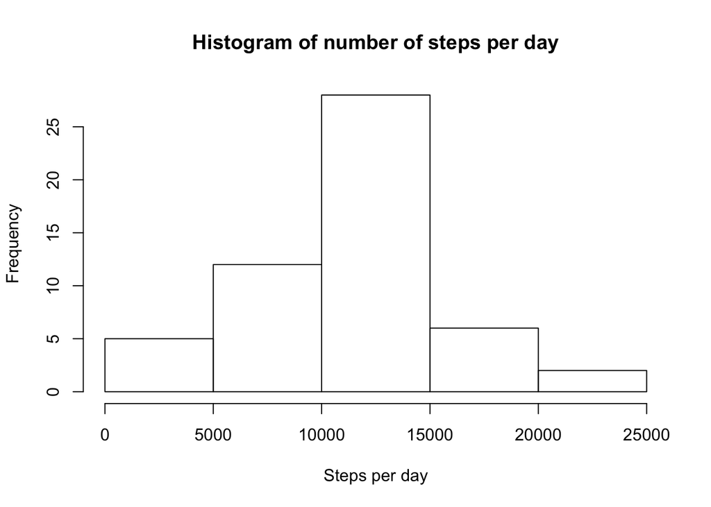

```r
hist(daystep$daystep,main = "Histogram of number of steps per day",xlab="Steps per day")
```

# Mean and median number of steps taken each day

```r
meanstep<-mean(daystep$daystep,na.rm = TRUE)
medianstep<-median(daystep$daystep,na.rm=TRUE)
meanstep
```

```
## [1] 10766.19
```

```r
medianstep
```

```
## [1] 10765
```